# final_project_part02_c

I-Ling Yeh

2020/11/2

## Load packages

```r
library(tidyverse)
```

```r
library(dplyr)
library(ggplot2)
library(visdat)
library(corrplot)
```

## Final project data

Reads in the data for the final project.

```r
data_url <- 'https://raw.githubusercontent.com/jyurko/INFSCI_2595_Fall_2020/master/HW/final_project/infsci_2595_final_project_data.csv'

df <- readr::read_csv(data_url, col_names = TRUE)
```

## Model training: Regression models-C

Separate the variables associated with Step 1 in Option B.

```r
step_1_df <- df %>% select(xA, xB, x01:x06, response_1) %>%
  mutate(xA = factor(xA),
         xB = factor(xB))
```

I will try out multiple candidate models, that is from simple to complex. These models are trained in `caret`.

```r
library(caret)
```

I will use 5-fold cross-validation with 3 repeats for this project.

```r
my_ctrl <- trainControl(method = "repeatedcv", number = 5, repeats = 3, savePredictions = TRUE)
```

I choose RMSE as my performance metric.

```r
my_metric <- "RMSE"
```

### Linear models

Let’s start out with a simple linear model, assuming linear additive terms for all inputs. Train and tune Linear additive model for providing a baseline comparison to the other models:

```r
set.seed(2001)
mod_1 <- train(response_1 ~ .,
               data = step_1_df,
               method = "lm",
               metric = my_metric,
               preProcess = c("center", "scale"),
               trControl = my_ctrl)

mod_1
```

```
## Linear Regression
##
## 2013 samples
##    8 predictor
##
## Pre-processing: centered (10), scaled (10)
## Resampling: Cross-Validated (5 fold, repeated 3 times)
## Summary of sample sizes: 1611, 1611, 1611, 1609, 1610, 1611, ...
## Resampling results:
##
##   RMSE     Rsquared   MAE
##   3.85924  0.4925767  2.791355
##
## Tuning parameter 'intercept' was held constant at a value of TRUE
```

Let’s slowly start to increase the complexity by considering interaction terms.

```r
model.matrix(response_1 ~ (.)^3, data = step_1_df) %>% dim()
```

```
## [1] 2013  151
```

Because we have so many terms when we include interactions, let’s use a regularized regression model. Train and tune regularized regression with Elastic net:

```r
set.seed(2001)
mod_2_default <- train(response_1 ~ (.)^3,
               data = step_1_df,
               method = "glmnet",
               metric = my_metric,
               preProcess = c("center", "scale"),
               trControl = my_ctrl)
mod_2_default
```

```
## glmnet
##
## 2013 samples
##    8 predictor
##
## Pre-processing: centered (150), scaled (150)
## Resampling: Cross-Validated (5 fold, repeated 3 times)
## Summary of sample sizes: 1611, 1611, 1611, 1609, 1610, 1611, ...
## Resampling results across tuning parameters:
##
##   alpha  lambda       RMSE      Rsquared   MAE
##   0.10   0.005603354  3.803288  0.5069810  2.754554
##   0.10   0.056033543  3.861416  0.4918961  2.787104
##   0.10   0.560335429  3.872972  0.4898413  2.778329
##   0.55   0.005603354  3.827837  0.5006647  2.768703
##   0.55   0.056033543  3.861129  0.4920849  2.781241
##   0.55   0.560335429  3.957474  0.4779041  2.809869
##   1.00   0.005603354  3.838820  0.4977909  2.777000
##   1.00   0.056033543  3.862705  0.4918944  2.778072
##   1.00   0.560335429  4.069338  0.4637990  2.881288
##
## RMSE was used to select the optimal model using the smallest value.
## The final values used for the model were alpha = 0.1 and lambda = 0.005603354.
```

```r
enet_grid <- expand.grid(alpha = seq(0.1, 0.9, by = 0.1),
                         lambda = exp(seq(-6, -3, length.out = 15)))

set.seed(2001)
mod_2_tune <- train(response_1 ~ (.)^3,
               data = step_1_df,
               method = "glmnet",
               tuneGrid = enet_grid,
               metric = my_metric,
               preProcess = c("center", "scale"),
               trControl = my_ctrl)
mod_2_tune
```

```
## glmnet
##
## 2013 samples
##    8 predictor
##
## Pre-processing: centered (150), scaled (150)
## Resampling: Cross-Validated (5 fold, repeated 3 times)
## Summary of sample sizes: 1611, 1611, 1611, 1609, 1610, 1611, ...
## Resampling results across tuning parameters:
##
##   alpha  lambda       RMSE      Rsquared   MAE
##   0.1    0.002478752  3.775940  0.5139758  2.740056
##   0.1    0.003071116  3.779556  0.5130592  2.741816
##   0.1    0.003805041  3.787894  0.5109311  2.746183
##   0.1    0.004714356  3.796486  0.5087312  2.750836
##   0.1    0.005840977  3.804901  0.5065655  2.755429
##   0.1    0.007236834  3.813279  0.5044056  2.760059
##   0.1    0.008966268  3.821104  0.5023893  2.764491
##   0.1    0.011108997  3.829051  0.5003357  2.769086
##   0.1    0.013763787  3.836422  0.4984260  2.773412
##   0.1    0.017053010  3.842846  0.4967583  2.777220
##   0.1    0.021128280  3.848855  0.4951982  2.780862
##   0.1    0.026177444  3.853363  0.4940231  2.783554
##   0.1    0.032433241  3.856987  0.4930740  2.785512
##   0.1    0.040184026  3.859365  0.4924457  2.786559
##   0.1    0.049787068  3.860917  0.4920330  2.787078
##   0.2    0.002478752  3.771157  0.5151954  2.736569
##   0.2    0.003071116  3.779986  0.5129542  2.741168
##   0.2    0.003805041  3.789399  0.5105477  2.746158
##   0.2    0.004714356  3.799104  0.5080626  2.751481
##   0.2    0.005840977  3.808352  0.5056868  2.756774
##   0.2    0.007236834  3.818124  0.5031740  2.762627
##   0.2    0.008966268  3.827419  0.5007762  2.768189
##   0.2    0.011108997  3.836570  0.4984080  2.773623
##   0.2    0.013763787  3.844504  0.4963511  2.778419
##   0.2    0.017053010  3.851029  0.4946424  2.782154
##   0.2    0.021128280  3.855927  0.4933515  2.784747
##   0.2    0.026177444  3.859123  0.4925065  2.786448
##   0.2    0.032433241  3.860941  0.4920269  2.787134
##   0.2    0.040184026  3.861492  0.4918796  2.786828
```

[output cut: 94 more lines]

```
##   0.9    0.004714356  3.825604  0.5012422  2.769289
##   0.9    0.005840977  3.839680  0.4975864  2.777026
##   0.9    0.007236834  3.852848  0.4941551  2.783439
##   0.9    0.008966268  3.859658  0.4923654  2.786727
##   0.9    0.011108997  3.860614  0.4921076  2.786815
##   0.9    0.013763787  3.860437  0.4921657  2.786166
##   0.9    0.017053010  3.860210  0.4922312  2.785290
##   0.9    0.021128280  3.860008  0.4922962  2.784285
##   0.9    0.026177444  3.859907  0.4923440  2.783146
##   0.9    0.032433241  3.860019  0.4923498  2.781906
##   0.9    0.040184026  3.860478  0.4922816  2.780587
##   0.9    0.049787068  3.861513  0.4920903  2.779373
##
## RMSE was used to select the optimal model using the smallest value.
## The final values used for the model were alpha = 0.2 and lambda = 0.002478752.
```

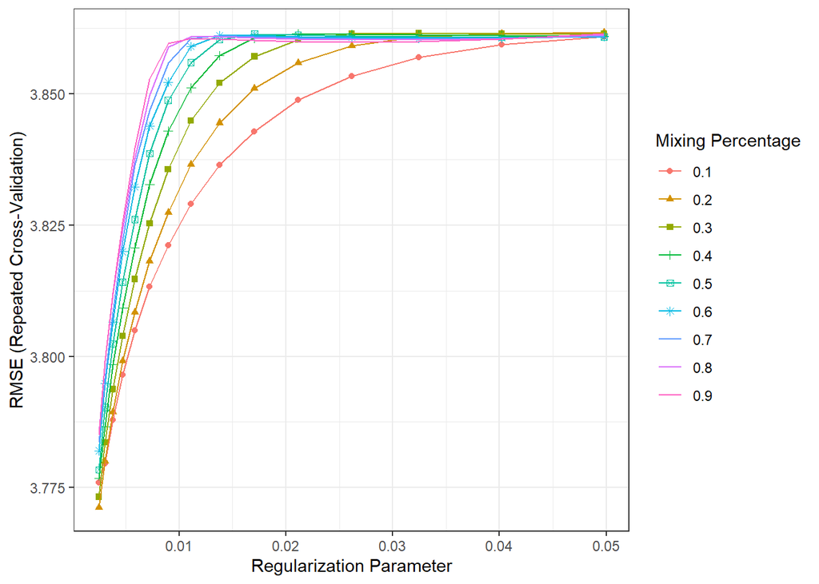

```r
ggplot(mod_2_tune) + theme_bw()
```

```r
mod_2_tune$bestTune
```

```
##    alpha      lambda
## 16   0.2 0.002478752
```

```r
coef(mod_2_tune$finalModel) %>% rownames()
```

```
##   [1] "(Intercept)"   "xAA2"          "xBB2"          "xBB3"
##   [5] "xBB4"          "x01"           "x02"           "x03"
##   [9] "x04"           "x05"           "x06"           "xAA2:xBB2"
##  [13] "xAA2:xBB3"     "xAA2:xBB4"     "xAA2:x01"      "xAA2:x02"
##  [17] "xAA2:x03"      "xAA2:x04"      "xAA2:x05"      "xAA2:x06"
##  [21] "xBB2:x01"      "xBB3:x01"      "xBB4:x01"      "xBB2:x02"
##  [25] "xBB3:x02"      "xBB4:x02"      "xBB2:x03"      "xBB3:x03"
##  [29] "xBB4:x03"      "xBB2:x04"      "xBB3:x04"      "xBB4:x04"
##  [33] "xBB2:x05"      "xBB3:x05"      "xBB4:x05"      "xBB2:x06"
##  [37] "xBB3:x06"      "xBB4:x06"      "x01:x02"       "x01:x03"
##  [41] "x01:x04"       "x01:x05"       "x01:x06"       "x02:x03"
##  [45] "x02:x04"       "x02:x05"       "x02:x06"       "x03:x04"
##  [49] "x03:x05"       "x03:x06"       "x04:x05"       "x04:x06"
##  [53] "x05:x06"       "xAA2:xBB2:x01" "xAA2:xBB3:x01" "xAA2:xBB4:x01"
##  [57] "xAA2:xBB2:x02" "xAA2:xBB3:x02" "xAA2:xBB4:x02" "xAA2:xBB2:x03"
```

[output cut: 23 more lines]

There are 114 non-zero features in regularized regression with Elastic net.

```r
coef(mod_2_tune$finalModel, s = mod_2_tune$bestTune$lambda) %>%
  as.matrix() %>%
  as.data.frame() %>%
  tibble::rownames_to_column("coef_name") %>%
  tibble::as_tibble() %>%
  purrr::set_names(c("coef_name", "coef_value")) %>%
  filter(coef_value != 0) %>%
  nrow()
```

```
## [1] 114
```

Train and tune Partial Least Squares:

```r
set.seed(2001)
mod_3 <- train(response_1 ~ .,
               data = step_1_df,
               method = "pls",
               metric = my_metric,
               preProcess = c("center", "scale"),
               trControl = my_ctrl)
mod_3
```

```
## Partial Least Squares
##
## 2013 samples
##    8 predictor
##
## Pre-processing: centered (10), scaled (10)
## Resampling: Cross-Validated (5 fold, repeated 3 times)
## Summary of sample sizes: 1611, 1611, 1611, 1609, 1610, 1611, ...
## Resampling results across tuning parameters:
##
##   ncomp  RMSE      Rsquared   MAE
##   1      4.217846  0.3920063  3.082135
##   2      3.939964  0.4715413  2.801699
##   3      3.872728  0.4890403  2.806631
##
## RMSE was used to select the optimal model using the smallest value.
## The final value used for the model was ncomp = 3.
```

### Non-linear models

Now let’s try out some more complex models that can learn non-linear patterns in the data. Train and tune Neural network:

```r
set.seed(2001)
mod_4_default <- train(response_1 ~ .,
               data = step_1_df,
               method = "nnet",
               metric = my_metric,
               preProcess = c("center", "scale"),
               trControl = my_ctrl,
               trace = FALSE,
               linout = TRUE)
mod_4_default
```

```
## Neural Network
##
## 2013 samples
##    8 predictor
##
## Pre-processing: centered (10), scaled (10)
## Resampling: Cross-Validated (5 fold, repeated 3 times)
## Summary of sample sizes: 1611, 1611, 1611, 1609, 1610, 1611, ...
## Resampling results across tuning parameters:
##
##   size  decay  RMSE      Rsquared   MAE
##   1     0e+00  3.995750  0.4543573  2.857208
##   1     1e-04  3.944195  0.4691526  2.819049
##   1     1e-01  3.890343  0.4841910  2.798231
##   3     0e+00  3.421422  0.5982577  2.481682
##   3     1e-04  3.380178  0.6052385  2.466329
##   3     1e-01  3.225767  0.6419108  2.361890
##   5     0e+00  2.923558  0.7038901  2.156778
##   5     1e-04  2.999015  0.6889298  2.212289
##   5     1e-01  2.886314  0.7140613  2.129228
##
## RMSE was used to select the optimal model using the smallest value.
## The final values used for the model were size = 5 and decay = 0.1.
```

```r
nnet_grid <- expand.grid(size = c(3, 5, 10, 15),
                         decay = exp(seq(-6, 3, length.out = 31)))

set.seed(2001)
mod_4_tune <- train(response_1 ~ .,
               data = step_1_df,
               method = "nnet",
               tuneGrid = nnet_grid,
               metric = my_metric,
               preProcess = c("center", "scale"),
               trControl = my_ctrl,
               trace = FALSE,
               linout = TRUE)
mod_4_tune
```

```
## Neural Network
##
## 2013 samples
##    8 predictor
##
## Pre-processing: centered (10), scaled (10)
## Resampling: Cross-Validated (5 fold, repeated 3 times)
## Summary of sample sizes: 1611, 1611, 1611, 1609, 1610, 1611, ...
## Resampling results across tuning parameters:
##
##   size  decay         RMSE      Rsquared   MAE
##    3     0.002478752  3.451935  0.5931895  2.472781
##    3     0.003345965  3.319688  0.6176649  2.437583
##    3     0.004516581  3.345062  0.6111805  2.427522
##    3     0.006096747  3.398734  0.6012755  2.495933
```

[output cut: 123 more lines]

```r
mod_4_tune$bestTune
```

```
##     size     decay
## 112   15 0.5488116
```

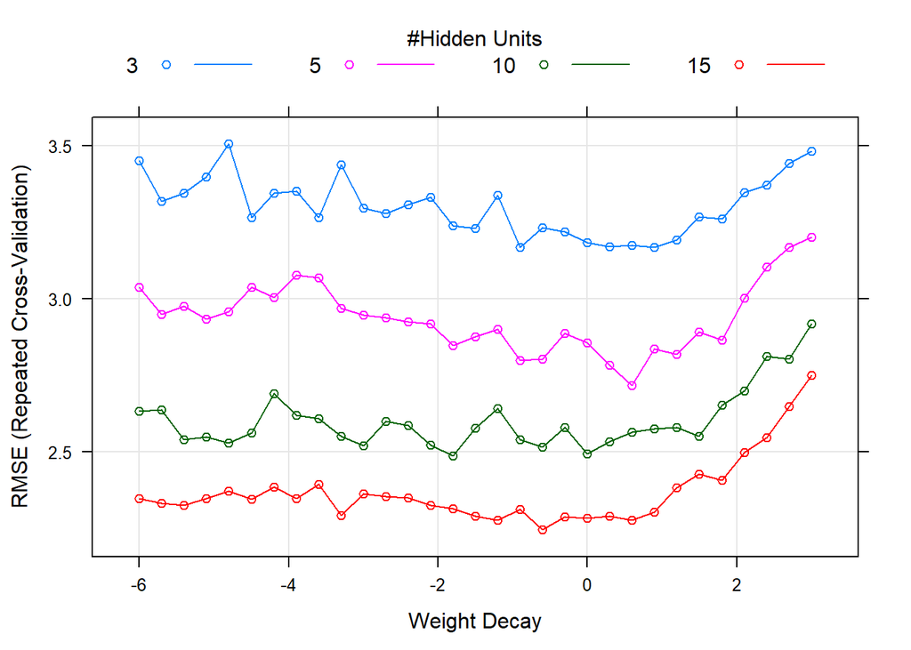

```r
plot(mod_4_tune, xTrans = log)
```

```r
library(NeuralNetTools)
```

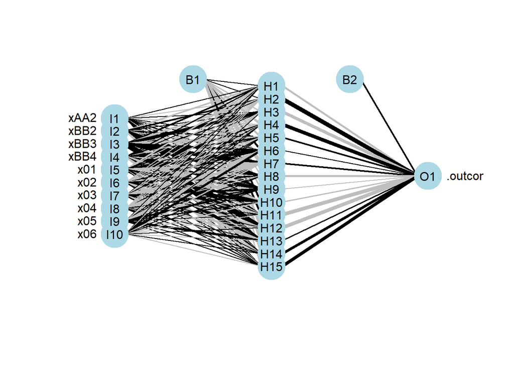

```r
plotnet(mod_4_tune$finalModel)
```

Train and tune Random Forest:

```r
set.seed(2001)
mod_5 <- train(response_1 ~ .,
                       data = step_1_df,
                       method = "rf",
                       metric = my_metric,
                       trControl = my_ctrl,
                       importance = TRUE)
mod_5
```

```
## Random Forest
##
## 2013 samples
##    8 predictor
##
## No pre-processing
## Resampling: Cross-Validated (5 fold, repeated 3 times)
## Summary of sample sizes: 1611, 1611, 1611, 1609, 1610, 1611, ...
## Resampling results across tuning parameters:
##
##   mtry  RMSE      Rsquared   MAE
##    2    3.066779  0.7378065  2.129886
##    6    2.246664  0.8359438  1.649521
##   10    2.231699  0.8344956  1.657414
##
## RMSE was used to select the optimal model using the smallest value.
## The final value used for the model was mtry = 10.
```

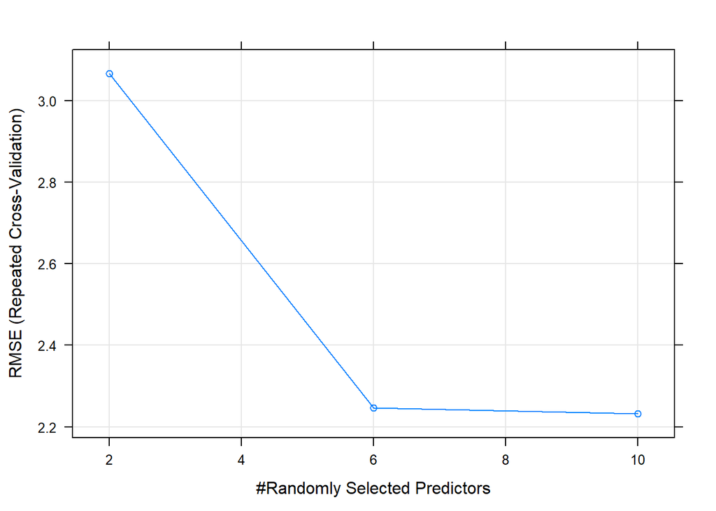

```r
plot(mod_5)
```

Train and tune boosted tree model with `xgboost`:

```r
set.seed(2001)
mod_6 <- train(response_1 ~ .,
                       data = step_1_df,
                       method = "xgbTree",
                       metric = my_metric,
                       trControl = my_ctrl,
                       importance = TRUE)
```

[output not shown]

[output cut: 4812 more lines]

[output not shown]

```r
mod_6
```

```
## eXtreme Gradient Boosting
##
## 2013 samples
##    8 predictor
##
## No pre-processing
## Resampling: Cross-Validated (5 fold, repeated 3 times)
## Summary of sample sizes: 1611, 1611, 1611, 1609, 1610, 1611, ...
## Resampling results across tuning parameters:
##
##   eta  max_depth  colsample_bytree  subsample  nrounds  RMSE      Rsquared
##   0.3  1          0.6               0.50        50      3.951954  0.4697116
##   0.3  1          0.6               0.50       100      3.961356  0.4653287
##   0.3  1          0.6               0.50       150      3.988989  0.4578283
##   0.3  1          0.6               0.75        50      3.939850  0.4719641
##   0.3  1          0.6               0.75       100      3.928836  0.4721934
##   0.3  1          0.6               0.75       150      3.955893  0.4650885
##   0.3  1          0.6               1.00        50      3.924565  0.4766885
##   0.3  1          0.6               1.00       100      3.922920  0.4744569
##   0.3  1          0.6               1.00       150      3.933285  0.4712104
##   0.3  1          0.8               0.50        50      3.964328  0.4661135
##   0.3  1          0.8               0.50       100      3.948147  0.4689171
##   0.3  1          0.8               0.50       150      3.956428  0.4658856
##   0.3  1          0.8               0.75        50      3.907170  0.4811314
##   0.3  1          0.8               0.75       100      3.912141  0.4771345
##   0.3  1          0.8               0.75       150      3.926806  0.4730088
##   0.3  1          0.8               1.00        50      3.921576  0.4774824
##   0.3  1          0.8               1.00       100      3.926412  0.4734904
##   0.3  1          0.8               1.00       150      3.932328  0.4714769
##   0.3  2          0.6               0.50        50      3.170284  0.6599851
##   0.3  2          0.6               0.50       100      2.993759  0.6952556
##   0.3  2          0.6               0.50       150      2.849716  0.7245128
##   0.3  2          0.6               0.75        50      3.083886  0.6821096
##   0.3  2          0.6               0.75       100      2.875989  0.7202595
##   0.3  2          0.6               0.75       150      2.743697  0.7452209
##   0.3  2          0.6               1.00        50      3.035711  0.6910832
##   0.3  2          0.6               1.00       100      2.857270  0.7240567
##   0.3  2          0.6               1.00       150      2.715766  0.7509056
##   0.3  2          0.8               0.50        50      3.042444  0.6875497
##   0.3  2          0.8               0.50       100      2.820563  0.7313003
```

[output cut: 181 more lines]

```
##   1.862862
##   1.807901
##   1.772700
##   1.779833
##   1.815481
##   1.741829
##   1.736461
##
## Tuning parameter 'gamma' was held constant at a value of 0
## Tuning
##  parameter 'min_child_weight' was held constant at a value of 1
## RMSE was used to select the optimal model using the smallest value.
## The final values used for the model were nrounds = 150, max_depth = 3, eta
##  = 0.3, gamma = 0, colsample_bytree = 0.8, min_child_weight = 1 and subsample
##  = 1.
```

```r
mod_6$bestTune
```

```
##    nrounds max_depth eta gamma colsample_bytree min_child_weight subsample
## 54     150         3 0.3     0              0.8                1         1
```

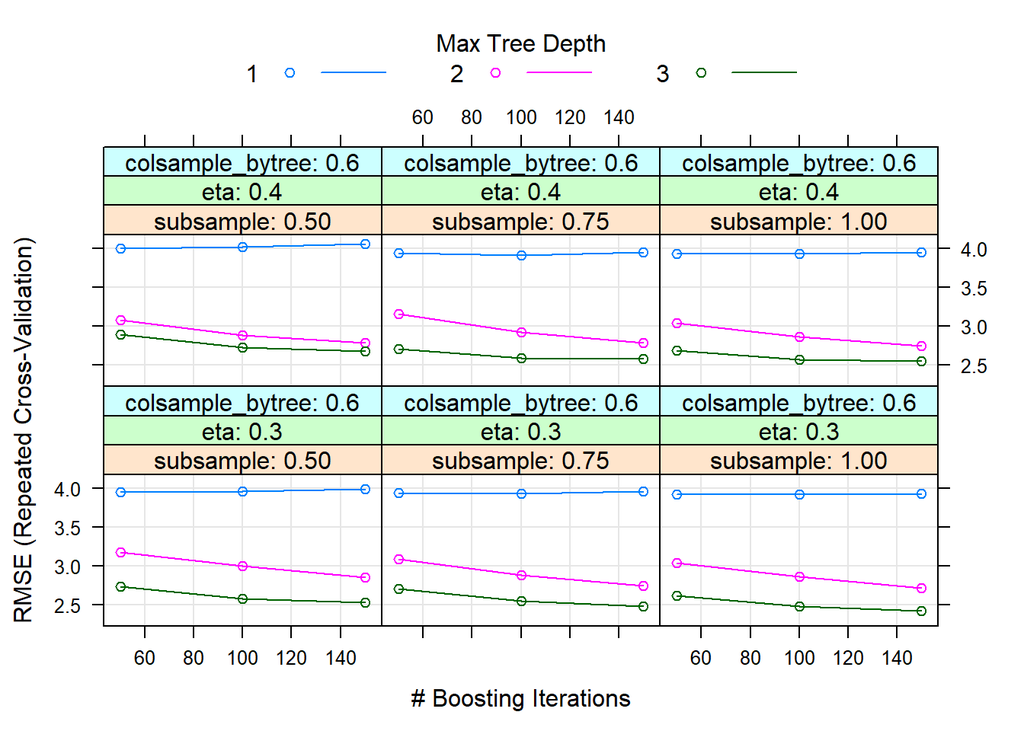

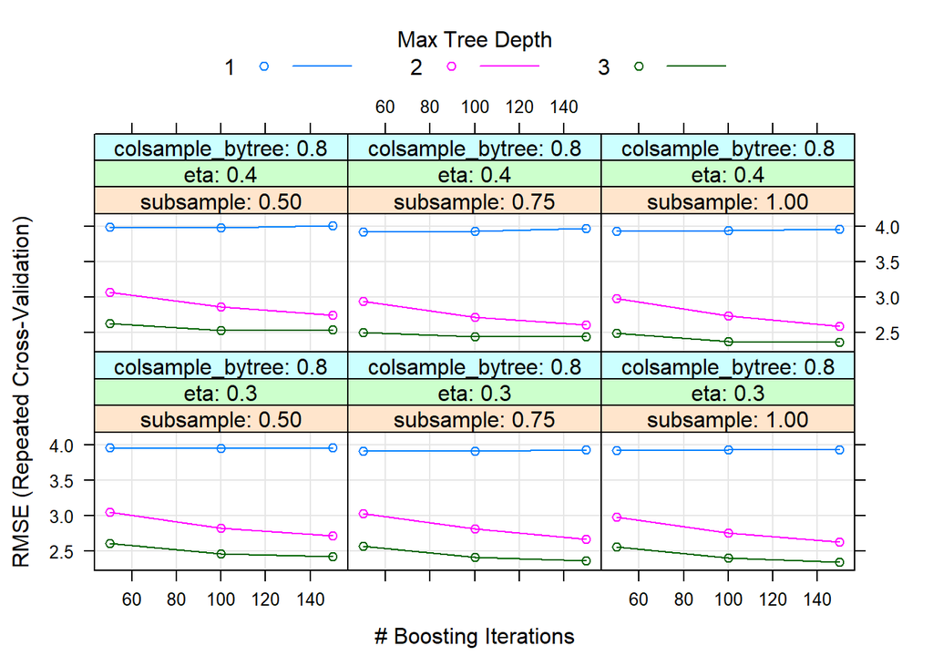

```r
plot(mod_6)
```

Train and tune SVM:

```r
set.seed(2001)
mod_7 <- train(response_1 ~ .,
               data = step_1_df,
               method = "svmRadial",
               metric = my_metric,
               preProcess = c("center", "scale"),
               trControl = my_ctrl)
mod_7
```

```
## Support Vector Machines with Radial Basis Function Kernel
##
## 2013 samples
##    8 predictor
##
## Pre-processing: centered (10), scaled (10)
## Resampling: Cross-Validated (5 fold, repeated 3 times)
## Summary of sample sizes: 1611, 1611, 1611, 1609, 1610, 1611, ...
## Resampling results across tuning parameters:
##
##   C     RMSE      Rsquared   MAE
##   0.25  3.579722  0.6018507  2.366264
##   0.50  3.206804  0.6866726  2.145850
##   1.00  2.760791  0.7686328  1.897083
##
## Tuning parameter 'sigma' was held constant at a value of 0.06938059
## RMSE was used to select the optimal model using the smallest value.
## The final values used for the model were sigma = 0.06938059 and C = 1.
```

### Compare models

Now we have fit all of the models, let’s compare the cross-validation performance metrics.

```r
regression_results = resamples(list(LM = mod_1,
                                    GLMNET_trips = mod_2_tune,
                                    PLS = mod_3,
                                    NNET = mod_4_tune,
                                    RF = mod_5,
                                    XGB = mod_6,
                                    SVM = mod_7))
```

Now we can visually compare the performance metrics.

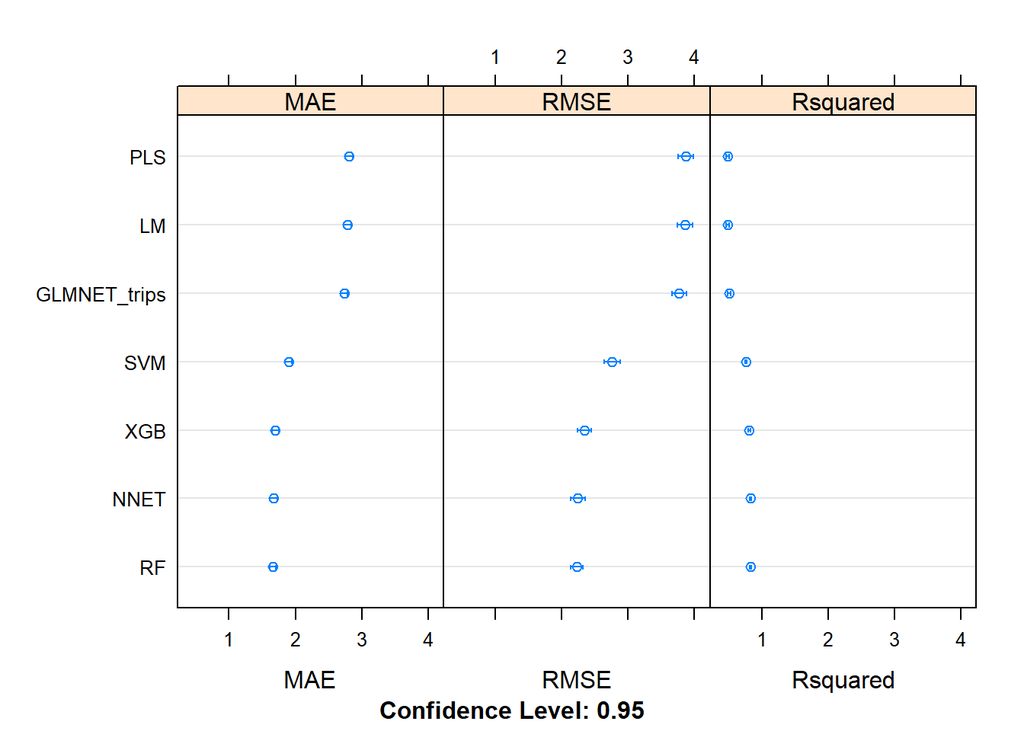

```r
dotplot(regression_results)
```

Zoom in to show RMSE:

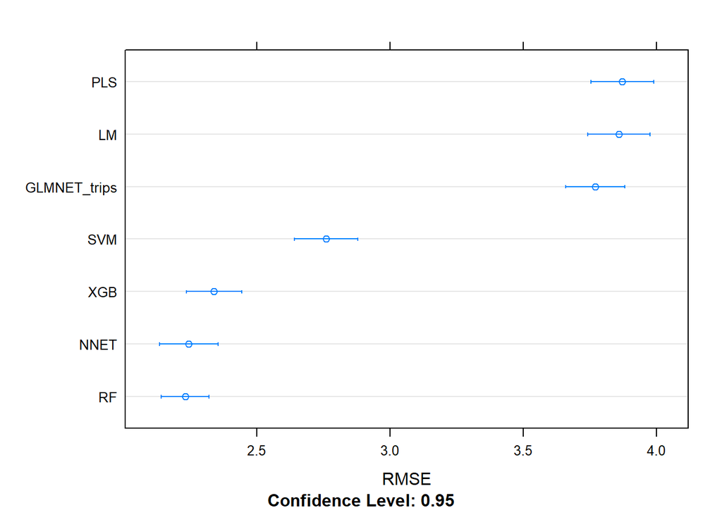

```r
dotplot(regression_results, metric = "RMSE")
```

Zoom in to show R-squared:

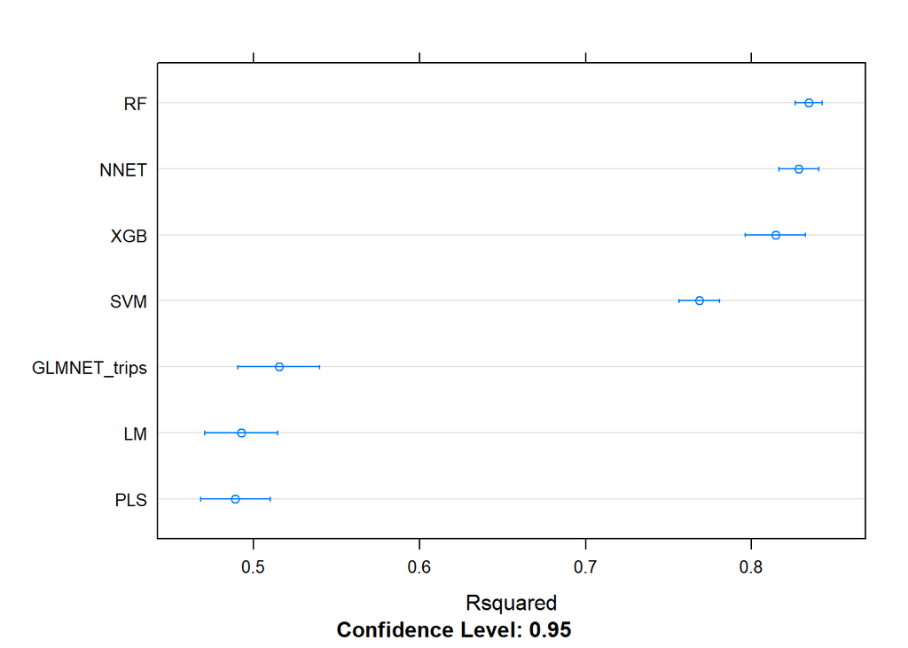

```r
dotplot(regression_results, metric = "Rsquared")
```

From the above, the random forest would be the best model. Let’s now visualize the random forest hold-out set predictions compared to the observations.

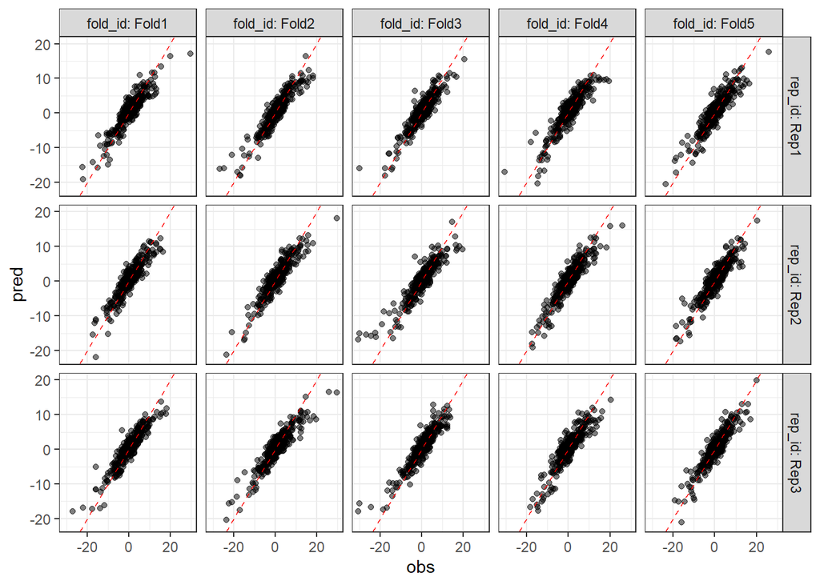

```r
mod_5$pred %>% tibble::as_tibble() %>%
  filter(mtry == mod_5$bestTune$mtry) %>%
  tidyr::separate(Resample,
                  c("fold_id", "rep_id"),
                  sep = "\\.",
                  remove = FALSE) %>%
  ggplot(mapping = aes(x = obs, y = pred)) +
  geom_point(alpha = 0.5) +
  geom_abline(slope = 1, intercept = 0,
              color = "red", linetype = "dashed") +
  facet_grid(rep_id ~ fold_id, labeller = "label_both") +
  theme_bw()
```

Compare the random forest to regularized regression model.

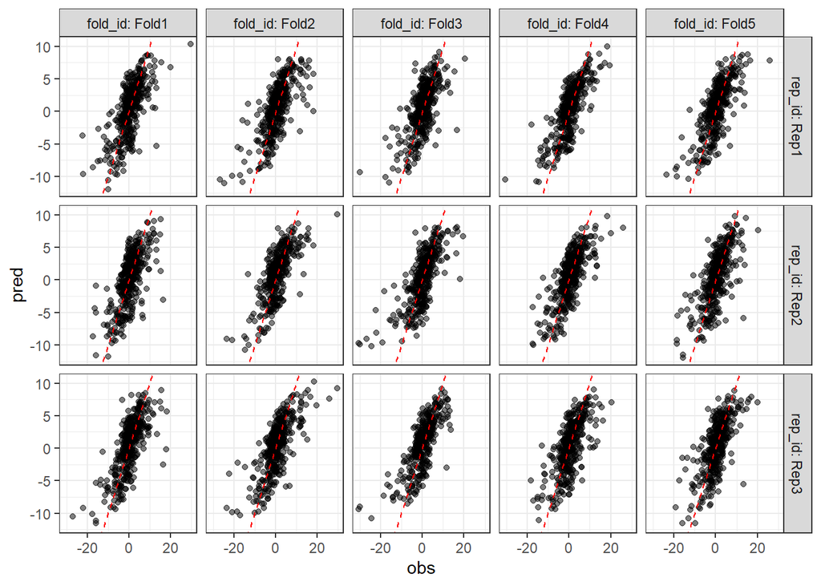

```r
mod_2_tune$pred %>% tibble::as_tibble() %>%
  filter(alpha == mod_2_tune$bestTune$alpha,
         lambda ==mod_2_tune$bestTune$lambda) %>%
  tidyr::separate(Resample,
                  c("fold_id", "rep_id"),
                  sep = "\\.",
                  remove = FALSE) %>%
  ggplot(mapping = aes(x = obs, y = pred)) +
  geom_point(alpha = 0.5) +
  geom_abline(slope = 1, intercept = 0,
              color = "red", linetype = "dashed") +
  facet_grid(rep_id ~ fold_id, labeller = "label_both") +
  theme_bw()
```

Now, plot the variable importance rankings in random forest.

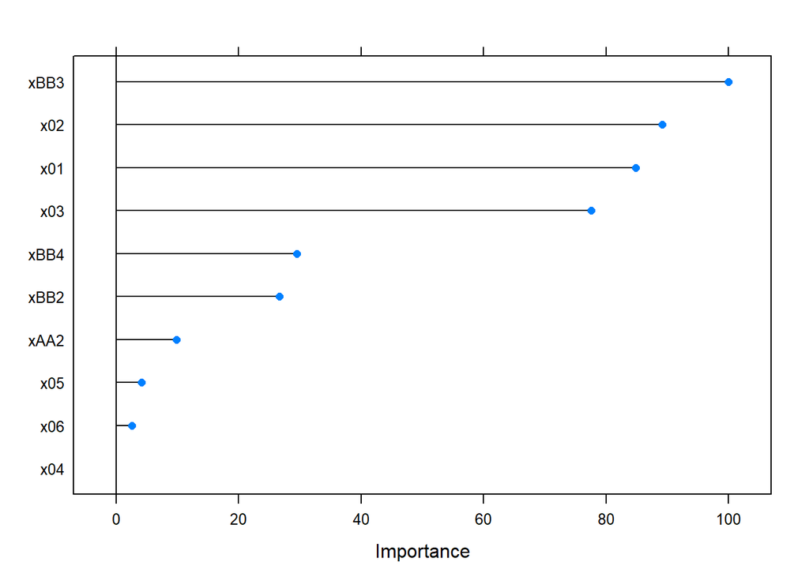

```r
plot(varImp(mod_5))
```